# Word Frequencies

Text as Data

Amber Boydstun & Cory Struthers

Spring 2025

### Introduction

The bag of words model is the prevailing approach to text representation. The fundamental concept is straightforward: we will represent each document by counting how many times each word appears in it. Think of taking all the words in a given document (or set of documents) of interest, and shaking them all up in a bag so they are no longer in order.

In this module, we’ll need the following packages:

```r
# Load packages
require(tidyverse)
require(quanteda)
require(quanteda.textstats)
require(quanteda.textplots)
library(stringr)
library(ggplot2)
library(ggpubr)

# Set working directory
setwd("~/Library/CloudStorage/Box-Box/A_teaching/POL290G_TextAsData/modules/data/")
getwd() # view working directory
```

We’ll demonstrate word frequencies with an example using (what was once) Twitter data.

During the 2016 presidential election campaigns, people noticed a peculiar trend. When then-presidential candidate Donald Trump posted positive tweets to Twitter, they came from an iPhone. When he posted negative tweets to Twitter, they came from an Android. Some speculated that Trump’s Android and iPhone tweets were therefore written by different people.

David Robinson, the author of the book “R for text mining,” collected Trump’s tweets from 12/14/2015-08/08/2016 and found that Trump’s Android tweets were angrier and more negative than iPhone tweets. Here, we are going to use the [Twitter data collected from David Robinson](http://varianceexplained.org/r/trump-tweets/) to examine which words were most common among Android-posted and iPhone-posted tweets.

### Load and tokenize the data

```r
# Import data frame
load(url("http://varianceexplained.org/files/trump_tweets_df.rda"))
View(trump_tweets_df)
sort(unique(trump_tweets_df$statusSource))
```

```
## [1] "<a href=\"http://instagram.com\" rel=\"nofollow\">Instagram</a>"
## [2] "<a href=\"http://twitter.com\" rel=\"nofollow\">Twitter Web Client</a>"
## [3] "<a href=\"http://twitter.com/#!/download/ipad\" rel=\"nofollow\">Twitter for iPad</a>"
## [4] "<a href=\"http://twitter.com/download/android\" rel=\"nofollow\">Twitter for Android</a>"
## [5] "<a href=\"http://twitter.com/download/iphone\" rel=\"nofollow\">Twitter for iPhone</a>"
```

```r
# Create new variable with phone type
# Note the regular expression, allowing us to only keep statusSource entries that include Twitter for iPad / iPhone / Android, retaining only that key term
# We also drop the entries that are in quotes to only capture tweets Trump wrote himself
# And we remove any urls OR any &amp; items

tweets_df <- trump_tweets_df %>%
    mutate(doc_id = row_number()) %>%
    select(doc_id, statusSource, text, created) %>%
    mutate(source = str_replace(statusSource, ".*Twitter for (.*?)<.*", "\\1")) %>%
    filter(source %in% c("iPhone", "Android")) %>%
    filter(!str_detect(text, '^"')) %>% # remove " at the start of each line
    mutate(text = str_replace_all(text, "https://t.co/[A-Za-z\\d]+ | &amp;", "")) %>%
    select(doc_id, source, text, created)

#tweets_df$doc_id <- as.character(tweets_df$doc_id)

head(tweets_df)
```

| doc_id | source | text | created |
| --- | --- | --- | --- |
| 1 | Android | My economic policy speech will be carried live at 12:15 P.M. Enjoy! | 2016-08-08 15:20:44 |
| 2 | iPhone | Join me in Fayetteville, North Carolina tomorrow evening at 6pm. Tickets now available at: https://t.co/Z80d4MYIg8 | 2016-08-08 13:28:20 |
| 3 | iPhone | #ICYMI: "Will Media Apologize to Trump?" https://t.co/ia7rKBmioA | 2016-08-08 00:05:54 |
| 4 | Android | Michael Morell, the lightweight former Acting Director of C.I.A., and a man who has made serious bad calls, is a total Clinton flunky! | 2016-08-07 23:09:08 |
| 5 | Android | The media is going crazy. They totally distort so many things on purpose. Crimea, nuclear, "the baby" and so much more. Very dishonest! | 2016-08-07 21:31:46 |
| 6 | Android | I see where Mayor Stephanie Rawlings-Blake of Baltimore is pushing Crooked hard. Look at the job she has done in Baltimore. She is a joke! | 2016-08-07 13:49:29 |

In this example, the unit of analysis is a tweet. We are interested in differences in term frequencies between two groups: tweets by iPhone and tweets by Android. As we’ve done before, we convert the raw text to corpus, then tokens, then dfm objects.

```r
# Convert text to corpus, view docvars
tweet_corp <- corpus(tweets_df, text_field="text")
head(docvars(tweet_corp),10)
```

|  | source | created |
| --- | --- | --- |
| 1 | Android | 2016-08-08 15:20:44 |
| 2 | iPhone | 2016-08-08 13:28:20 |
| 3 | iPhone | 2016-08-08 00:05:54 |
| 4 | Android | 2016-08-07 23:09:08 |
| 5 | Android | 2016-08-07 21:31:46 |
| 6 | Android | 2016-08-07 13:49:29 |
| 7 | iPhone | 2016-08-07 02:19:37 |
| 8 | iPhone | 2016-08-07 02:03:39 |
| 9 | Android | 2016-08-07 01:53:45 |
| 10 | iPhone | 2016-08-06 20:04:08 |

```r
# Transform to tokens
tweet_toks <- tweet_corp  %>%
    tokens(remove_punct = TRUE,
           remove_numbers = TRUE,
           remove_symbols = TRUE,
           remove_url = TRUE) %>%
    tokens_tolower() %>%
    tokens_remove(stopwords("english"))
head(tweet_toks)
```

```
## Tokens consisting of 6 documents and 2 docvars.
## 1 :
## [1] "economic" "policy"   "speech"   "carried"  "live"     "p.m"      "enjoy"
##
## 2 :
##  [1] "join"         "fayetteville" "north"        "carolina"     "tomorrow"
##  [6] "evening"      "6pm"          "tickets"      "now"          "available"
##
## 3 :
## [1] "#icymi"    "media"     "apologize" "trump"
##
## 4 :
##  [1] "michael"     "morell"      "lightweight" "former"      "acting"
##  [6] "director"    "c.i.a"       "man"         "made"        "serious"
## [11] "bad"         "calls"
## [ ... and 3 more ]
##
## 5 :
##  [1] "media"   "going"   "crazy"   "totally" "distort" "many"    "things"
##  [8] "purpose" "crimea"  "nuclear" "baby"    "much"
## [ ... and 1 more ]
##
## 6 :
##  [1] "see"            "mayor"          "stephanie"      "rawlings-blake"
##  [5] "baltimore"      "pushing"        "crooked"        "hard"
##  [9] "look"           "job"            "done"           "baltimore"
## [ ... and 1 more ]
```

```r
# Find collocations
tweet_coll <- textstat_collocations(tweet_toks, size = 2:3, min_count = 10)
tweet_coll
```

|  | collocation | count | count_nested | length | lambda | z |
| --- | --- | --- | --- | --- | --- | --- |
| 1 | hillary clinton | 74 | 74 | 2 | 6.118932 | 21.804838 |
| 2 | make america | 49 | 49 | 2 | 7.415469 | 19.902828 |
| 3 | crooked hillary | 115 | 115 | 2 | 8.326532 | 19.327917 |
| 4 | ted cruz | 39 | 39 | 2 | 7.442386 | 18.316507 |
| 5 | america great | 37 | 37 | 2 | 4.724562 | 18.225846 |
| 6 | #makeamericagreatagain #trump2016 | 48 | 40 | 2 | 5.682478 | 17.715508 |
| 7 | last night | 16 | 16 | 2 | 7.435190 | 14.547935 |
| 8 | president obama | 13 | 13 | 2 | 6.032750 | 13.771115 |
| 9 | see soon | 12 | 12 | 2 | 6.093687 | 13.699850 |
| 10 | republican party | 12 | 12 | 2 | 6.724506 | 13.132112 |

[output cut: 18 more lines]

```r
# Add collocations to existing tokens document
# Note that any tokens also captured in the collocations get captured in both forms
tweet_toks_all <- tokens_compound(tweet_toks, tweet_coll, concatenator = " ") %>%
    tokens_select(padding=FALSE) %>% # remove padding
    tokens_wordstem # stem words after adding collocations
tail(tweet_toks_all,15)
```

```
## Tokens consisting of 15 documents and 2 docvars.
## 1491 :
## [1] "#foxnew"                           "poll"
## [3] "thank"                             "#makeamericagreatagain #trump2016"
##
## 1492 :
## [1] "#makeamericagreatagain #trump2016"
##
## 1493 :
##  [1] "love"      "see"       "union"     "non-union" "member"    "alik"
##  [7] "defect"    "trump"     "creat"     "job"       "like"      "one"
## [ ... and 5 more ]
##
## 1494 :
##  [1] "hope"      "worker"    "demand"    "@teamster" "rep"       "endors"
##  [7] "donald"    "j"         "trump"     "nobodi"    "know"      "job"
## [ ... and 4 more ]
##
## 1495 :
## [1] "way"            "south carolina" "big"            "crowd"
## [5] "look"           "forward"
##
## 1497 :
##  [1] "hank"      "greenberg" "former"    "aig"       "gave"      "million"
##  [7] "@jebbush"  "campaign"  "month"     "ago"       "happi"     "total"
## [ ... and 2 more ]
##
## [ reached max_ndoc ... 9 more documents ]
```

### Create document-feature matrix (DFM)

After tokenization, we move to the next step. We use `dfm()` to convert the corpus of documents to a document-feature matrix (DFM), which is essentially a massive table where every row is a document in the corpus and every column is a token (recall, word or phrase).

The values in the cells show the number of times a token appears in the document.

```r
# Create a document-feature matrix
tweet_dfm <- dfm(tweet_toks_all)
tweet_dfm
```

```
## Document-feature matrix of: 1,175 documents, 2,400 features (99.62% sparse) and 2 docvars.
##     features
## docs econom polici speech carri live p.m enjoy join fayettevill north
##    1      1      1      1     1    1   1     1    0           0     0
##    2      0      0      0     0    0   0     0    1           1     1
##    3      0      0      0     0    0   0     0    0           0     0
##    4      0      0      0     0    0   0     0    0           0     0
##    5      0      0      0     0    0   0     0    0           0     0
##    6      0      0      0     0    0   0     0    0           0     0
## [ reached max_ndoc ... 1,169 more documents, reached max_nfeat ... 2,390 more features ]
```

```r
# Number of features (i.e., unique tokens)
nfeat(tweet_dfm)
```

```
## [1] 2400
```

```r
# Examine sums across documents
head(colSums(tweet_dfm),50)
```

```
##      econom      polici      speech       carri        live         p.m
##           4           6          29           2          10          12
##       enjoy        join fayettevill       north    carolina    tomorrow
##          36          47           1           8           7          24
##        even         6pm      ticket         now       avail      #icymi
##          33           2          16          51           3           2
##       media      apolog       trump     michael       morel lightweight
##          37           5          57           5           1          15
##      former         act    director       c.i.a         man        made
##           3           4           2           1           5          22
##     serious         bad        call       total     clinton      flunki
##           3          54          22          59          31           3
##          go       crazi     distort        mani       thing      purpos
##          49          11           2          56          19           3
##      crimea     nuclear        babi        much   dishonest         see
##           3           3           1          31          23          21
##       mayor    stephani
##           3           1
```

### Calculate basic word frequencies

```r
# Get top features
topfeatures(tweet_dfm, decreasing = TRUE)
```

```
##           thank           great      #trump2016           peopl            just
##             221             137             111              91              77
##             get crooked hillari           total           trump            mani
##              65              63              59              57              56
```

The `textstat_frequency()` function in `quanteda.textstats package` is also a useful function for calculating term frequencies in a corpus of text data. In addition to providing feature counts, it ranks features and provides each feature’s document frequency.

```r
# Get frequency and ranking
textstat_frequency(tweet_dfm)
```

|  | feature | frequency | rank | docfreq | group |
| --- | --- | --- | --- | --- | --- |
| 1 | thank | 221 | 1 | 221 | all |
| 2 | great | 137 | 2 | 132 | all |
| 3 | #trump2016 | 111 | 3 | 111 | all |
| 4 | peopl | 91 | 4 | 86 | all |
| 5 | just | 77 | 5 | 77 | all |
| 6 | get | 65 | 6 | 61 | all |
| 7 | crooked hillari | 63 | 7 | 62 | all |
| 8 | total | 59 | 8 | 59 | all |
| 9 | trump | 57 | 9 | 55 | all |
| 10 | mani | 56 | 10 | 54 | all |

[output cut: 2390 more lines]

### Trim (with caution)

Some DFMs are very large, involving hundreds of thousands of documents and millions of features. Features within those documents may be used rarely across the whole corpus, or used many times but only in a single document. Many text analysis methods do not infer meaning from terms mentioned very few times, and retaining all terms in really large corpora increases computational complexity.

Thus, the researcher can “trim” the dfm to exclude infrequent terms using `dfm_trim`. When used appropriately, trimming can decrease processing time without losing quality. In fact, reducing *sparseness* or *sparsity* in the matrix (i.e., the proportion of cells that have zero counts) is particularly important for more complex computational tasks in order to avoid over-fitting and using memory.

- `min_termfreq` removes any features that occur less than *n* times in the corpus (no matter the distribution across documents).
- `min_docfreq` removes any features that occur in less than *n* times across *documents*.
- `docfreq_type` (an option) specifies a count or proportion.

```r
# Pipe grouping through trimming step using the groups function (so that later we can count up the feature frequencies within each source)
# In the first row you can either dfm the dfm or re-dfm the original tokens document (tweet_toks_all)
tweet_dfm_trim <- dfm(tweet_dfm) %>%
                       dfm_trim(min_termfreq = 10, min_docfreq = 10, docfreq_type = "count") %>%
                       dfm_group(groups = source)
print(tweet_dfm_trim)
```

```
## Document-feature matrix of: 2 documents, 261 features (4.02% sparse) and 1 docvar.
##          features
## docs      speech live p.m enjoy join tomorrow even ticket now media
##   Android     20    5  12    19    1        2   18      2  33    30
##   iPhone       9    5   0    17   46       22   15     14  18     7
## [ reached max_nfeat ... 251 more features ]
```

Depending on the question, ubiquitous terms can also have little meaning. `quanteda` offers a `max` equivalent of the above but we don’t suggest using it as often, in part because common terms may not be distributed evenly across groups we care about.

### Calculate basic word frequencies

The `textstat_frequency()` function in `quanteda.textstats package` is a useful function for calculating term frequencies in a corpus of text data. In addition to providing feature counts, it ranks features and provides each feature’s document frequency.

Note that you must use `group` to get group-level frequencies when you apply `textstat_frequency`.

```r
# Calculate frequencies by group
tweet_words_freq <- dfm(tweet_dfm_trim) %>%
    textstat_frequency(groups = source) # Grouping the term frequencies by source
head(tweet_words_freq)
```

|  | feature | frequency | rank | docfreq | group |
| --- | --- | --- | --- | --- | --- |
| 1 | great | 73 | 1 | 1 | Android |
| 2 | peopl | 63 | 2 | 1 | Android |
| 3 | just | 57 | 3 | 1 | Android |
| 4 | total | 49 | 4 | 1 | Android |
| 5 | crooked hillari | 49 | 4 | 1 | Android |
| 6 | mani | 45 | 6 | 1 | Android |

Let’s also plot the count of the top 15 most frequent words used in Trump’s tweets from Android and from iPhone.

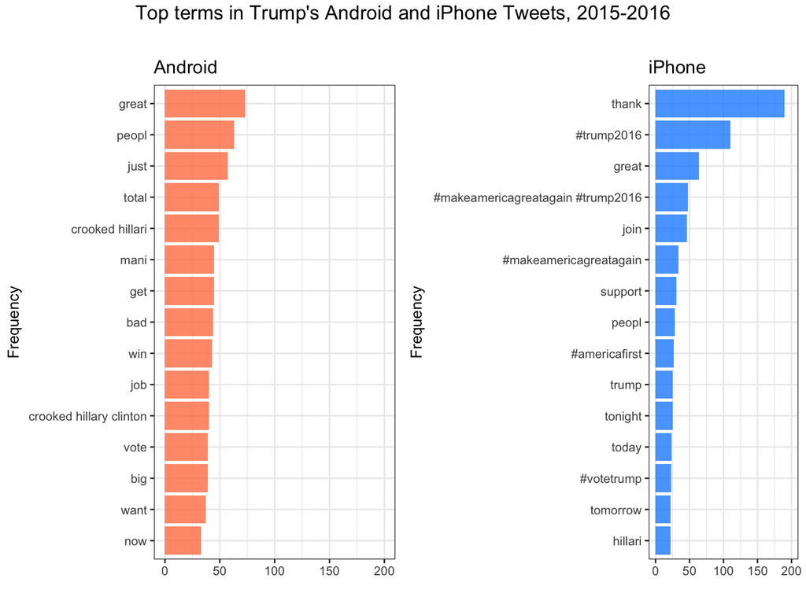

```r
# First create dfs with only the top 15 features
android15_df <- tweet_words_freq %>%
    filter(group == "Android") %>%
    head(15)
iphone15_df <- tweet_words_freq %>%
    filter(group == "iPhone") %>%
    head(15)

# Plot and arrange side by side
android15_plot <- ggplot(data = android15_df, aes(x = reorder(feature, frequency), y = frequency)) +
    geom_col(stat = "identity", alpha = 0.8, fill = "coral",
             position = position_dodge(width = 0.8)) +
    scale_y_continuous(limits = c(0, 200)) +
    xlab("Frequency") + ylab("") +
    ggtitle("Android") +
    coord_flip() +
    theme_bw()

iphone15_plot <- ggplot(data = iphone15_df, aes(x = reorder(feature, frequency), y = frequency)) +
    geom_col(stat = "identity", alpha = 0.8, fill = "dodgerblue",
             position = position_dodge(width = 0.8)) +
    scale_y_continuous(limits = c(0, 200)) +
    xlab("Frequency") + ylab("") +
    ggtitle("iPhone") +
    coord_flip() +
    theme_bw()

ggpubr::ggarrange(android15_plot, iphone15_plot) %>%
  annotate_figure(top = text_grob("Top terms in Trump's Android and iPhone Tweets, 2015-2016\n",  size = 14))
```

```r
        #the \n gives us a pretty line break
```

By plotting the top 15 most frequent words used from Trump’s Android and iPhone, we can see that “crooked hillary clinton” and “bad” is mentioned more often in Android tweets than iPhone tweets. We also observe features like “#trump2016”, “#makeamericagreatagain”, and “support”, which have more positive implications.

### Visualize word frequencies

We can also use the `textplot_wordcloud` function to create wordcloud of the trimmed dfm.

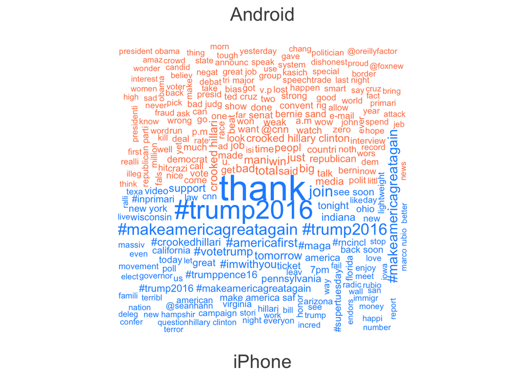

```r
set.seed(132) # Set seed so figure can be reproduced
textplot_wordcloud(tweet_dfm_trim, comparison = TRUE, max_words = 250, color = c("coral","dodgerblue"), min_size=0.9)
```

### Apply TF-IDF

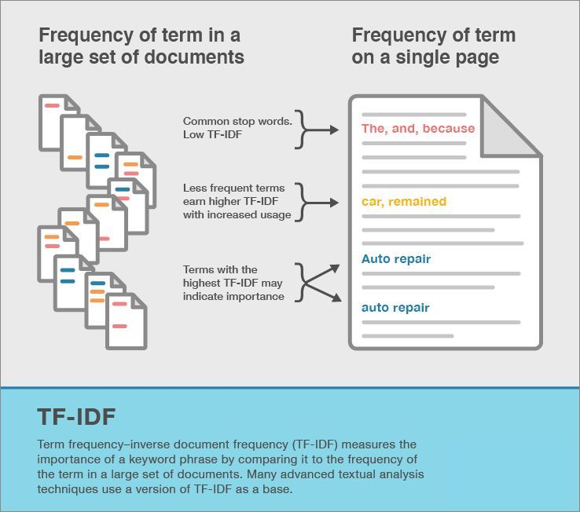

The example above used a bag-of-words approach to analyzing Trump’s tweets, with the objective of taking a simple count of how many times each term appeared.

Let’s see how things change if we use another bag-of-words approach with an alternative conceptualization of relative term importance or uniqueness: TF-IDF (Term Frequency-Inverse Document Frequency). The general intuition of TF-IDF is that term frequency should increase with the number of times it appears in a document after its frequency across all documents is accounted for. TF-IDF accounts for the fact that some terms appear frequently across all documents, which makes the term less meaningful conceptually. It is calculated as follows:

TF = (# of times a term appears in a document) / (# of terms in a document) X

IDF = Log[(# of documents) / (# of documents containing the word)]

`quanteda` uses the function `dfm_tfidf` to calculate TF-IDF. Let’s first apply it to the whole tweet corpus.

```r
# Let's trim again in the same way as we did above, using the same version of our tokenization that includes the collocations
# But this time we won't group by source b/c we're using TF-IDF
tweet_dfm_tfidf <- dfm(tweet_toks_all) %>%
  dfm_trim(min_termfreq = 10, min_docfreq = 10, docfreq_type = "count")  %>%
  dfm_tfidf()
print(tweet_dfm_tfidf)
```

```
## Document-feature matrix of: 1,175 documents, 261 features (98.12% sparse) and 2 docvars.
##     features
## docs  speech     live      p.m    enjoy    join tomorrow     even   ticket
##    1 1.60764 2.070038 1.990857 1.513735 0       0        0        0
##    2 0       0        0        0        1.39794 1.689827 1.551524 1.865918
##    3 0       0        0        0        0       0        0        0
##    4 0       0        0        0        0       0        0        0
##    5 0       0        0        0        0       0        0        0
##    6 0       0        0        0        0       0        0        0
##     features
## docs      now    media
##    1 0        0
##    2 1.371068 0
##    3 0        1.501836
##    4 0        0
##    5 0        1.501836
##    6 0        0
## [ reached max_ndoc ... 1,169 more documents, reached max_nfeat ... 251 more features ]
```

The terms are now weighted, according to their rareness relative to other documents.

Here’s where things get tricky. Recall that we want to compare Android and iPhone tweets, which means we need to group frequencies. With basic word frequency, we group the dfm into the two sources before applying `textstat_frequency` to get word counts. As illustrated in the calculation above, with TF-IDF, word count is weighted by the *relative* appearance across documents.

But what is the number of documents when we group? When we don’t group?

Let’s first apply `dfm_tfidf` *after* we assign tweets to their source group.

```r
# This time convert to a grouped dfm, trim, and calculate tf-idf
tweet_dfm_tfidf_grouped <- dfm(tweet_toks_all) %>%
  dfm_group(group=source) %>%
  dfm_trim(min_termfreq = 10, min_docfreq = 10, docfreq_type = "count")  %>% # removing docfreq because of groups %>%
  dfm_tfidf()
print(tweet_dfm_tfidf_grouped)
```

```
## Document-feature matrix of: 2 documents, 0 features (0.00% sparse) and 1 docvar.
```

**Oops, what went wrong here?**

Trying again, this time trimming first before grouping (so we don’t end up trimming everything!):

```r
# Convert to trimmed dfm, group, and calculate tf-idf
tweet_dfm_tfidf_grouped <- dfm(tweet_toks_all) %>%
  dfm_trim(min_termfreq = 10, min_docfreq = 10, docfreq_type = "count")  %>%
  dfm_group(group=source) %>%
  dfm_tfidf()
print(tweet_dfm_tfidf_grouped)
```

```
## Document-feature matrix of: 2 documents, 261 features (4.02% sparse) and 1 docvar.
##          features
## docs      speech live     p.m enjoy join tomorrow even ticket now media
##   Android      0    0 3.61236     0    0        0    0      0   0     0
##   iPhone       0    0 0           0    0        0    0      0   0     0
## [ reached max_nfeat ... 251 more features ]
```

By grouping, we now have only two documents. Just as we did for word frequency, let’s observe and plot TF-IDF scores for Android and iPhone tweets. Note that `quanteda` requires the option `force=TRUE` to generate grouped frequencies. *Forcing* something should give us pause. `quanteda`’s authors are telling us to use the option with caution! We’ll see why momentarily.

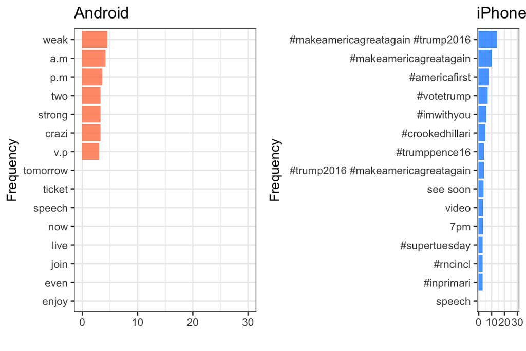

```r
# Generate frequency lists
tweet_tfidf_freq_grouped <- dfm(tweet_dfm_tfidf_grouped) %>%
    textstat_frequency(groups = source, force=TRUE)

# Create dfs with top 15 features
android15_tfidf <- tweet_tfidf_freq_grouped %>%
    filter(group == "Android") %>%
    arrange(desc(frequency)) %>%
    head(15)
iphone15_tfidf <- tweet_tfidf_freq_grouped %>%
    filter(group == "iPhone") %>%
    arrange(desc(frequency)) %>%
    head(15)

# Plot and arrange side by side
android15_tfidf_plot <- ggplot(data = android15_tfidf , aes(x = reorder(feature, frequency), y = frequency)) +
    geom_col(stat = "identity", alpha = 0.8, fill = "coral",
             position = position_dodge(width = 0.8)) +
    scale_y_continuous(limits = c(0, 30)) +
    xlab("Frequency") + ylab("") +
    ggtitle("Android") +
    coord_flip() +
    theme_bw()

iphone15_tfidf_plot <- ggplot(data = iphone15_tfidf, aes(x = reorder(feature, frequency), y = frequency)) +
    geom_col(stat = "identity", alpha = 0.8, fill = "dodgerblue",
             position = position_dodge(width = 0.8)) +
    scale_y_continuous(limits = c(0, 30)) +
    xlab("Frequency") + ylab("") +
    ggtitle("iPhone") +
    coord_flip() +
    theme_bw()

ggpubr::ggarrange(android15_tfidf_plot, iphone15_tfidf_plot)
```

First observe how many terms have zeros are in the `tweet_tfidf_freq_grouped` dataframe compared to `tweet_words_freq`.

```r
head(count(tweet_tfidf_freq_grouped, frequency),10)
```

|  | frequency | n |
| --- | --- | --- |
| 1 | 0.00000 | 480 |
| 2 | 3.01030 | 4 |
| 3 | 3.31133 | 5 |
| 4 | 3.61236 | 2 |
| 5 | 3.91339 | 1 |
| 6 | 4.21442 | 2 |
| 7 | 4.51545 | 1 |
| 8 | 5.11751 | 1 |
| 9 | 6.02060 | 1 |
| 10 | 6.92369 | 1 |

```r
head(count(tweet_words_freq, frequency),10)
```

|  | frequency | n |
| --- | --- | --- |
| 1 | 1 | 15 |
| 2 | 2 | 20 |
| 3 | 3 | 28 |
| 4 | 4 | 24 |
| 5 | 5 | 47 |
| 6 | 6 | 35 |
| 7 | 7 | 31 |
| 8 | 8 | 44 |
| 9 | 9 | 33 |
| 10 | 10 | 29 |

The grouped TF-IDF approach produces 480/498 zeros, whereas a zero value isn’t present (or possible) for the word frequency approach. Why does this happen? Let’s calculate the TF-IDF for a common term that appears in the `tweet_words_freq`, “great” in both Android and iPhone. Recall that TF-IDF is calculated as:

**(# of times a term appears in a document/# of terms in a document) X (log(# of documents/# of documents containing the term)**

```r
# Android
print(android15_df)
```

```
##                    feature frequency rank docfreq   group
## 1                    great        73    1       1 Android
## 2                    peopl        63    2       1 Android
## 3                     just        57    3       1 Android
## 4                    total        49    4       1 Android
## 5          crooked hillari        49    4       1 Android
## 6                     mani        45    6       1 Android
## 7                      get        45    6       1 Android
## 8                      bad        44    8       1 Android
## 9                      win        43    9       1 Android
## 10                     job        40   10       1 Android
## 11 crooked hillary clinton        40   10       1 Android
## 12                    vote        39   12       1 Android
## 13                     big        39   12       1 Android
## 14                    want        37   14       1 Android
## 15                     now        33   15       1 Android
```

```r
rowSums(tweet_dfm_trim)
```

```
## Android  iPhone
##    3443    2457
```

```r
(73/3443)*log(2/2)
```

```
## [1] 0
```

```r
# iPhone
print(iphone15_df)
```

```
##                               feature frequency rank docfreq  group
## 248                             thank       190    1       1 iPhone
## 249                        #trump2016       110    2       1 iPhone
## 250                             great        64    3       1 iPhone
## 251 #makeamericagreatagain #trump2016        48    4       1 iPhone
## 252                              join        46    5       1 iPhone
## 253            #makeamericagreatagain        34    6       1 iPhone
## 254                           support        31    7       1 iPhone
## 255                             peopl        28    8       1 iPhone
## 256                     #americafirst        27    9       1 iPhone
## 257                             trump        25   10       1 iPhone
## 258                           tonight        25   10       1 iPhone
## 259                             today        24   12       1 iPhone
## 260                        #votetrump        23   13       1 iPhone
## 261                          tomorrow        22   14       1 iPhone
## 262                           hillari        22   14       1 iPhone
```

```r
rowSums(tweet_dfm_trim)
```

```
## Android  iPhone
##    3443    2457
```

```r
(64/2457)*log(2/2)
```

```
## [1] 0
```

Both result in 0! Why? Because we grouped our dfms by source, “great” shows up across *all two* documents. IDF tells us that because the term shows up in both documents, it does not meaningfully distinguish Trump’s tweets from Android versus tweets from iPhone and so makes the TF-IDF score 0. This inference is a little extreme given our question about relative differences between term usage across both sources. TF-IDF approaches oftentimes increase sparsity, adding zeros for terms that appear across all documents (or groups).

Returning to weighted approaches with groups, let’s now apply `dfm_tfidf` and group *after* weights are assigned and plot.

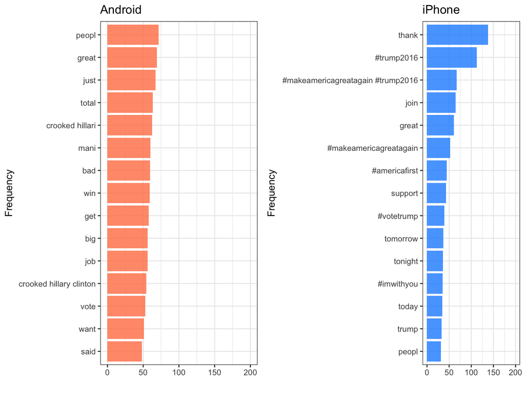

```r
# Using our ungrouped tfidf
tweet_dfm_tfidf_freq <- textstat_frequency(tweet_dfm_tfidf, groups = source, force=TRUE)
View(tweet_dfm_tfidf_freq)

# Create dfs with top 15 features
android15_tfidf <- tweet_dfm_tfidf_freq %>%
    filter(group == "Android") %>%
    arrange(desc(frequency)) %>%
    head(15)
iphone15_tfidf <- tweet_dfm_tfidf_freq %>%
    filter(group == "iPhone") %>%
    arrange(desc(frequency)) %>%
    head(15)

# Plot and arrange side by side
android15_tfidf_plot <- ggplot(data = android15_tfidf , aes(x = reorder(feature, frequency), y = frequency)) +
    geom_col(stat = "identity", alpha = 0.8, fill = "coral",
             position = position_dodge(width = 0.8)) +
    scale_y_continuous(limits = c(0, 200)) +
    xlab("Frequency") + ylab("") +
    ggtitle("Android") +
    coord_flip() +
    theme_bw()

iphone15_tfidf_plot = ggplot(data = iphone15_tfidf, aes(x = reorder(feature, frequency), y = frequency)) +
    geom_col(stat = "identity", alpha = 0.8, fill = "dodgerblue",
             position = position_dodge(width = 0.8)) +
    scale_y_continuous(limits = c(0, 200)) +
    xlab("Frequency") + ylab("") +
    ggtitle("iPhone") +
    coord_flip() +
    theme_bw()

ggpubr::ggarrange(android15_tfidf_plot, iphone15_tfidf_plot)
```

What do we observe? Now the output closely resembles the basic word frequency output; the order of some terms has changed, but top features across Android and iPhone overall are nearly identical. This happens because the TF-IDF scores are calculating rareness based on the whole corpus of tweets. In other words, the “TF-IDF then group” approach does not weigh *differences* between groups as heavily.

Like most TAD approaches, there is often not a right or wrong way to use word frequency approaches to make inferences. What’s more right or more wrong depends on the research question, hypothesis, and overarching research design. Generally, we need to consider the unit of analysis – specifically, what unit should be considered the “document” – before using weighting approaches. It’s worth noting that more groups in the grouping variable provides more variation in the TF-IDF calculation, reducing the number of zeros.

So, were Trump’s Android tweets more or less negative than Trump’s iPhone tweets? If it were our research project, we’d probably use both word frequency, TF-IDF, and manual content analysis in descriptive inference. We’d also probably apply sentiment analysis instead of word frequency approaches, which we’ll turn to next.

### Homework

#### Discussion Question:

1. Say you had ten poems, five describing the winter season and five describing the summer. The words “snow” and “cold” appear a handful of times in the winter poems and not at all in the summer poems. Imagine the result of applying the TF-IDF measure we’ve discussed in this module to these poems. Would the result adequately capture the importance of the words “cold” and “snow” to the winter concept? How about under different applications of the TF-IDF measure?

#### Project Questions (show your work):

1. Generate a list of the top terms/concepts in the data you tokenized from the pre-processing module (or another corpus, if you prefer).
2. Now generate a list of the top terms/concepts by group (e.g., by year).
3. Create a word cloud of top terms representing each group How might we interpret these results?
4. Now repeat steps #2 and #3 this time based on TF-IDF. How might we interpret these results?
5. Finally, discuss: what worked and what didn’t, and why? Explain the similarities and differences between your two approaches and what you learned.